# Homework 4

## Configuración inicial

```r
# Preparing libraries
library(ggplot2)
library(dplyr)

# Loading dataframe
diamonds <- read.csv('diamonds.csv')

str(diamonds)
```

```
'data.frame':   1000 obs. of  10 variables:
 $ carat  : num  0.31 1.5 0.9 1.01 0.33 1.08 1.07 0.33 0.44 1 ...
 $ cut    : chr  "Ideal" "Good" "Premium" "Ideal" ...
 $ color  : chr  "G" "G" "H" "F" ...
 $ clarity: chr  "VS1" "SI2" "VS2" "VS2" ...
 $ depth  : num  62.4 64.3 62.8 60.9 63.2 62 61.6 59.5 62 58.6 ...
 $ table  : num  55 57 58 58 56 55 58 59 57 61 ...
 $ price  : int  802 8190 3810 7411 1109 6779 5453 743 1255 6989 ...
 $ x      : num  4.35 7.29 6.17 6.43 4.45 6.62 6.6 4.53 4.87 6.57 ...
 $ y      : num  4.33 7.2 6.13 6.47 4.44 6.57 6.56 4.48 4.91 6.5 ...
 $ z      : num  2.71 4.66 3.86 3.93 2.81 4.09 4.05 2.68 3.02 3.83 ...
```

## Agregando geometrías

### 1. Dispersión

#### 1.1. Construya un gráfico de dispersión colocando en la estética carat (eje x) versus price (eje y), luego devuelva el gráfico.

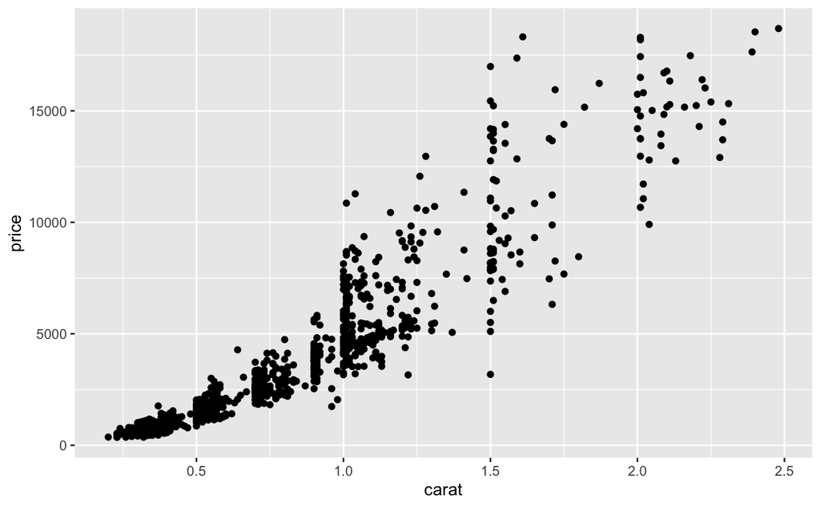

```r
scatter_plot = ggplot(diamonds, aes(x = carat, y = price)) +
  geom_point()
scatter_plot
```

#### 1.2. Edite la estética y mapee el color con la variable clarity.

```r
scatter_plot = ggplot(diamonds, aes(x = carat, y = price, color = clarity)) +
  geom_point()
```

#### 1.3. Devuelva el gráfico con esta modificación.

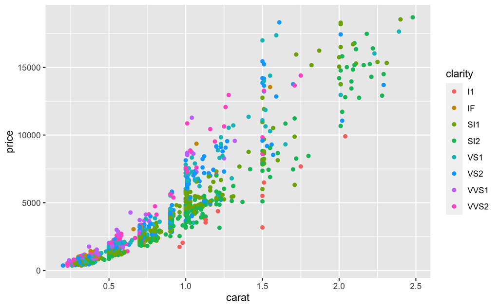

```r
scatter_plot
```

### 2. Histograma

#### 2.1. Construya el tipo de geometría histograma para la variable price. Configure el parámetro bins con el valor 40 y devuelva el gráfico.

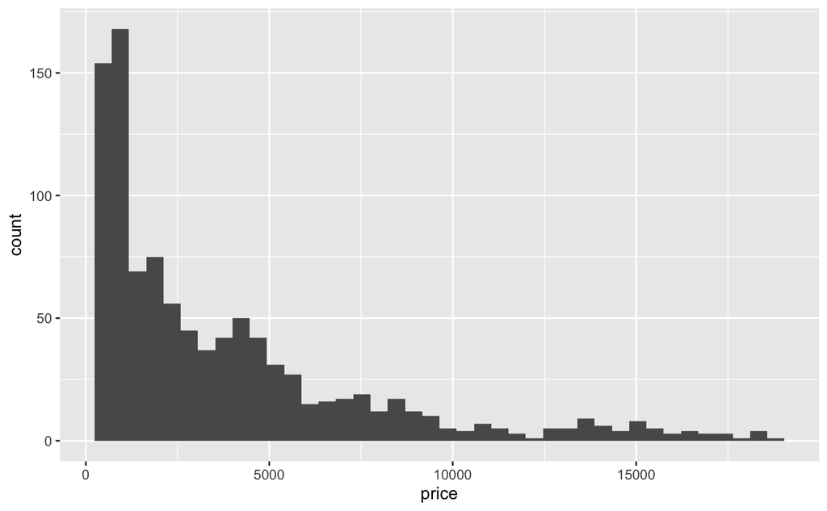

```r
histogram_plot = ggplot(diamonds, aes(x = price)) +
  geom_histogram(bins = 40)
histogram_plot
```

#### 2.2. Agregue una escala logarítmica de base 10 y devuelva el gráfico para ver la diferencia.

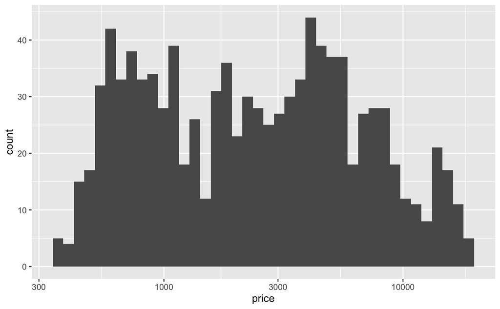

```r
histogram_plot = ggplot(diamonds, aes(x = price)) +
  geom_histogram(bins = 40) +
  scale_x_log10()

histogram_plot
```

### 3. Boxplots

#### 3.1. Construya un gráfico de cajas colocando en la estética la variable cut (eje x) versus price (eje y). Agregue una escala logarítmica por defecto y por último devuelva el gráfico.

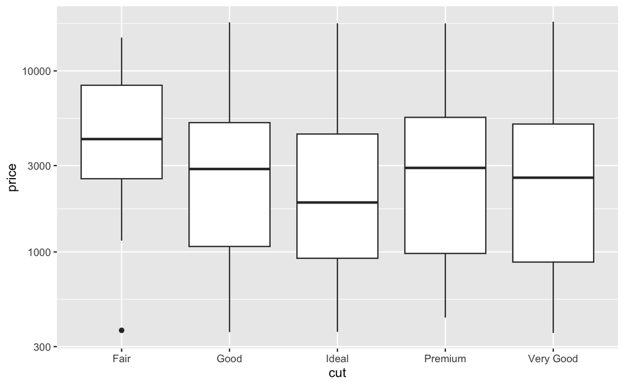

```r
box_plot = ggplot(diamonds, aes(x = cut, y = price)) +
  geom_boxplot() +
  scale_y_log10()

box_plot
```

#### 3.2. Edite el color de cada caja con el parámetro fill dentro de la estética y asignando la variable cut. Por último devuelva el gráfico.

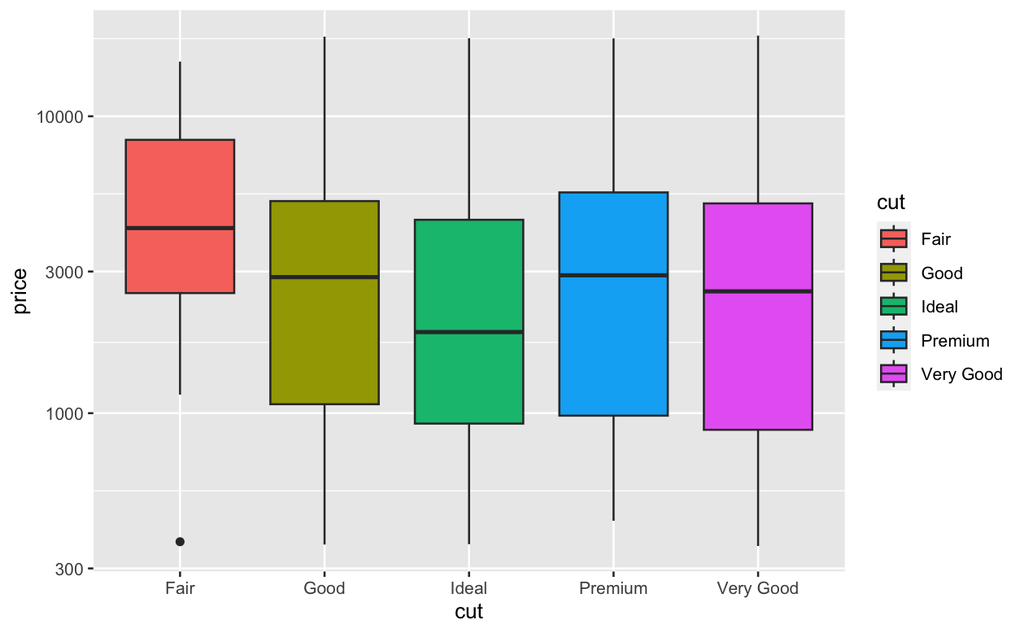

```r
box_plot = ggplot(diamonds, aes(x = cut, y = price, fill = cut)) +
  geom_boxplot() +
  scale_y_log10()

box_plot
```

### 4. Faceting

#### 4.1. Filtre diamonds por la variable price que sea mayor a 1000 y por cut que contenga las categorías Good, Ideal y Premium. Luego asigne el resultado a la variable filtered_price.

```r
filtered_price <- diamonds %>%
  filter(price > 1000 & cut %in% c("Good", "Ideal", "Premium"))

filtered_price
```

| carat | cut | color | clarity | depth | table | price | x | y | z |
| --- | --- | --- | --- | --- | --- | --- | --- | --- | --- |
| 1.50 | Good | G | SI2 | 64.3 | 57.0 | 8190 | 7.29 | 7.20 | 4.66 |
| 0.90 | Premium | H | VS2 | 62.8 | 58.0 | 3810 | 6.17 | 6.13 | 3.86 |
| 1.01 | Ideal | F | VS2 | 60.9 | 58.0 | 7411 | 6.43 | 6.47 | 3.93 |
| 1.08 | Ideal | G | VS1 | 62.0 | 55.0 | 6779 | 6.62 | 6.57 | 4.09 |
| 1.07 | Premium | G | SI1 | 61.6 | 58.0 | 5453 | 6.60 | 6.56 | 4.05 |
| 0.44 | Ideal | H | IF | 62.0 | 57.0 | 1255 | 4.87 | 4.91 | 3.02 |
| 1.00 | Premium | G | VS1 | 58.6 | 61.0 | 6989 | 6.57 | 6.50 | 3.83 |
| 1.30 | Premium | J | SI2 | 61.1 | 61.0 | 5140 | 7.00 | 6.95 | 4.26 |
| 1.11 | Premium | E | SI2 | 61.0 | 60.0 | 4177 | 6.68 | 6.66 | 4.07 |
| 0.51 | Ideal | E | SI2 | 62.7 | 53.0 | 1265 | 5.12 | 5.09 | 3.20 |

[output cut: 536 more lines]

#### 4.2. Utilice la variable filtered_price para construir un gráfico de barras, en la estética configure x = cut, y = depth.

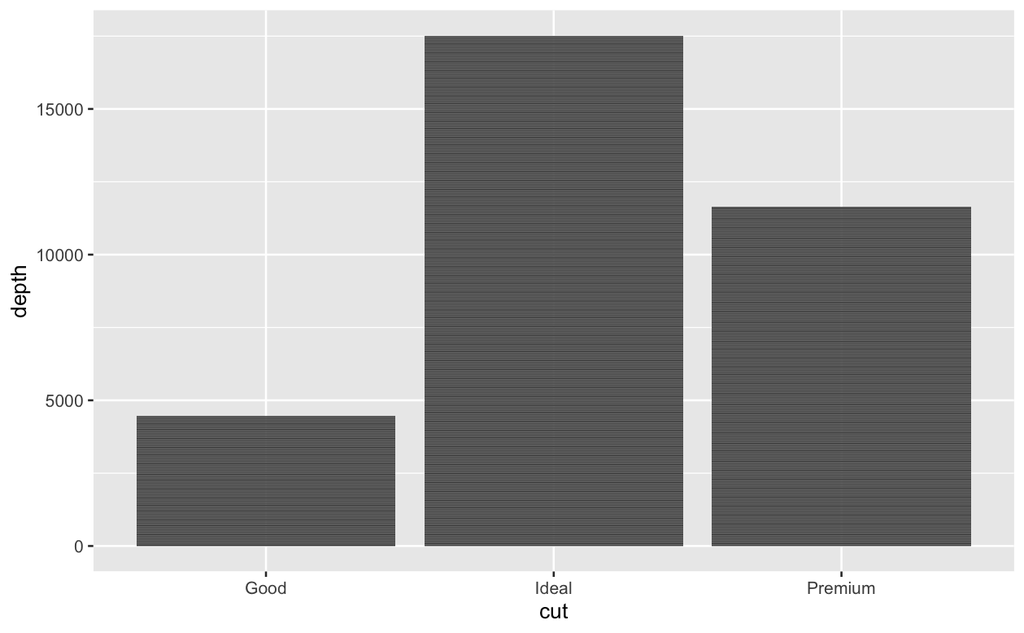

```r
bars_plot = ggplot(filtered_price, aes(x = cut, y = depth)) +
  geom_bar(stat = "identity")

bars_plot
```

#### 4.3. Por último aplique faceting para la variable clarity y devuelva la parcela de gráficos.

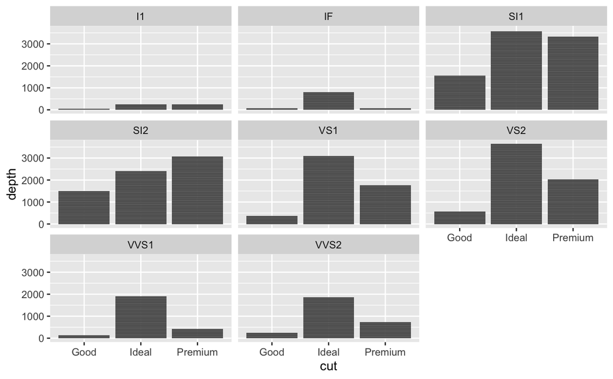

```r
bars_plot = ggplot(filtered_price, aes(x = cut, y = depth)) +
  geom_bar(stat = "identity") +
  facet_wrap(~ clarity)

bars_plot
```

#### 4.4. Edite la estética y configure el parámetro fill con la variable clarity. Luego devuelva la parcela de gráficos con esta modificación.

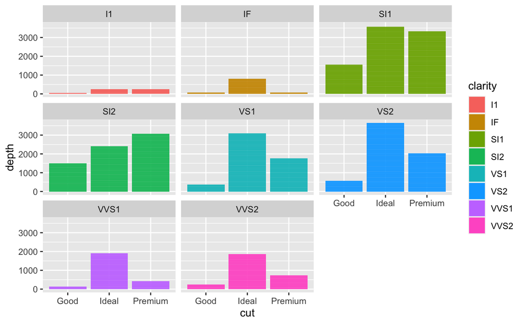

```r
bars_plot = ggplot(filtered_price, aes(x = cut, y = depth, fill = clarity)) +
  geom_bar(stat = "identity") +
  facet_wrap(~ clarity)

bars_plot
```

## Grouping and summarizing

### 1. Utilice diamonds para construir un agrupamiento por la variable cut, luego aplique summarize para encontrar la media de las variables x, y, z (los nombres de los valores sumarizados serán mediaX, mediaY, mediaZ, respectivamente). Asigne el resultado a la variable median_dimension_diamond, por último imprima la variable.

```r
median_dimension_diamond <- diamonds %>%
                              group_by(cut) %>%
                              summarize(mediaX = mean(x), mediaY = mean(y), mediaZ = mean(z))
print(median_dimension_diamond)
```

| cut | mediaX | mediaY | mediaZ |
| --- | --- | --- | --- |
| Fair | 6.417143 | 6.335357 | 4.147857 |
| Good | 5.819053 | 5.834632 | 3.635579 |
| Ideal | 5.530775 | 5.541400 | 3.416825 |
| Premium | 5.916070 | 5.873152 | 3.591284 |
| Very Good | 5.665955 | 5.696545 | 3.512318 |

### 2. Utilice diamonds para filtrar por la variable cut igual a Premium. Luego agrupe por la variable clarity y utilice summarize para encontrar minimo y maximo de price (los nombres de los valores sumarizados serán minPrice y maxPrice, respectivamente). Asigne el resultado a la variable cut_premium e imprima el valor de la variable.

```r
cut_premium <- diamonds %>%
                 filter(cut == "Premium") %>%
                 group_by(clarity) %>%
                 summarize(minPrice = min(price), maxPrice = max(price))

print(cut_premium)
```

| clarity | minPrice | maxPrice |
| --- | --- | --- |
| I1 | 2046 | 9905 |
| IF | 694 | 1020 |
| SI1 | 500 | 18295 |
| SI2 | 434 | 16783 |
| VS1 | 523 | 17642 |
| VS2 | 454 | 17433 |
| VVS1 | 552 | 11279 |
| VVS2 | 698 | 8722 |

### 3. Construya un gráfico de barras y utilice cut_premium como set de datos, configure x=clarity, y=maxPrice y el color de relleno (fill) con la variable clarity. Por último devuelva el gráfico.

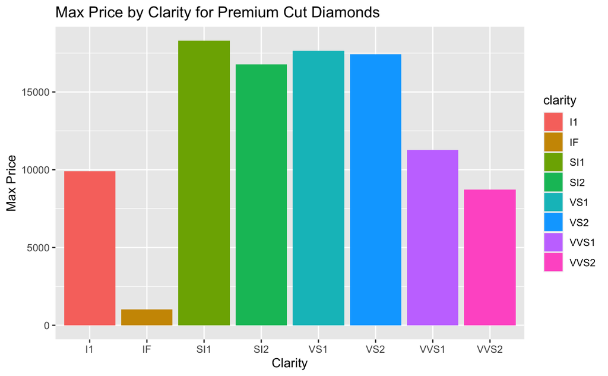

```r
ggplot(cut_premium, aes(x = clarity, y = maxPrice, fill = clarity)) +
  geom_bar(stat = "identity") +
  labs(x = "Clarity", y = "Max Price") +
  ggtitle("Max Price by Clarity for Premium Cut Diamonds")
```